# Tips and Tricks with Jupyter Notebooks

## Part 3: Publishing your own Resources

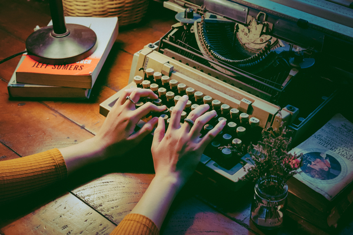

```python
from image_renderer import image_renderer
image_renderer(basewidth=600,image_path='../assets/typewriter.jpg')
```

Photo by Min An from [Pexels](https://www.pexels.com/photo/person-using-typewriter-1448709/)

### Preparing Jupyter notebooks so they can be exported as static html pages.

- Consider a solution where you can hide all the coded inputs, but you keep the outputs you wish to show
- Any code you want to show can be written in markdown and encapsulated with ```
- In the last cell paste the following within a Code cell at the base of the notebook:

```
%%html
<style type="text/css">
div.jp-InputArea {
    display:none;
}
div.input {
    display:none;
}
</style>
```

This will hide coded inputs!!

Here's a sample report before and after all cells are run:

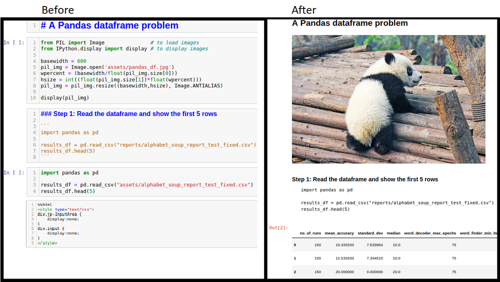

```python
image_renderer(basewidth=1000,image_path='../assets/sample_report_before_and_after.png')
```

As an example, you should be able to see that the dataframe in the bottom output cells is visible, whilst the input code for this is hidden.

In order to view all cells again, the last hidden html cell will need to be clicked on and switched back to markdown. Otherwise, you can restart the kernel and clear outputs.

When you are happy with the report, you can download it as html:

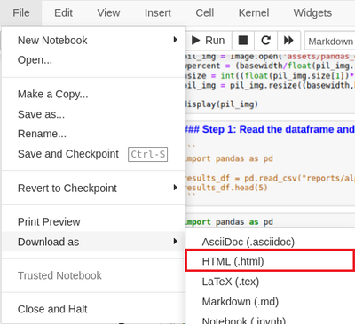

```python
image_renderer(basewidth=400,image_path='../assets/download_as_html.png')
```

### Final considerations for deploying html pages

- It's true Jupyter notebooks can be previewed in GitHub but they can appear messy if you need to hide code
- In this solution, you can hide code and push html files to GitHub as part of an easy free deployment.
- Simply add https://htmlpreview.github.io/? as a precursor to the link for your html report:

Example:

https://htmlpreview.github.io/?https://github.com/Kremzeeq/alphabet_soup/blob/master/alphabet_soup_pandas_problem.html

If your report has multiple pages, use these as hyperlinks to help tell your story!

[Next | Part 4: Creating Interactive Dashboards](https://htmlpreview.github.io/?https://github.com/Kremzeeq/jupyter_notebooks_tips_and_tricks/blob/main/webpages/tips_and_tricks_p4.html)

```python
%%html
<style type="text/css">
div.jp-InputArea {
    display:none;
}
div.input {
    display:none;
}
</style>
```